# MATH1005 Lab10 Worksheet

T-test

© University of Sydney 2022

# 1 T-test

In his original paper W.S. Gossett (“Student”) demonstrated his new testing technique on various examples. One was where 10 patients tried two different drugs, “Dextro” and “Laevo”, designed to increase sleep time.

1. Dextro
- Below is the difference in sleep time (in hours) after 10 patients were give “Dextro”.

```r
dextro = c(.7, -1.6, -.2, -1.2, -.1, 3.4, 3.7, .8, 0, 2)
```

- Determine the sample mean and SD.

```r
# type your code here
mean = mean(dextro)
sigma = sd(dextro) # sample sd
mean
```

```
## [1] 0.75
```

```r
sigma
```

```
## [1] 1.78901
```

- Is it reasonable to assume that this is a sample from an “approximately normal box”? Use some plots to check this.

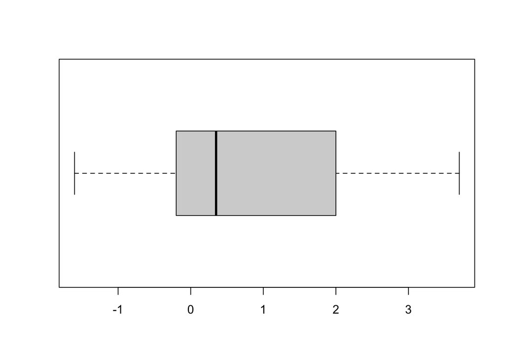

```r
# type your code here
boxplot(dextro,horizontal = TRUE)
```

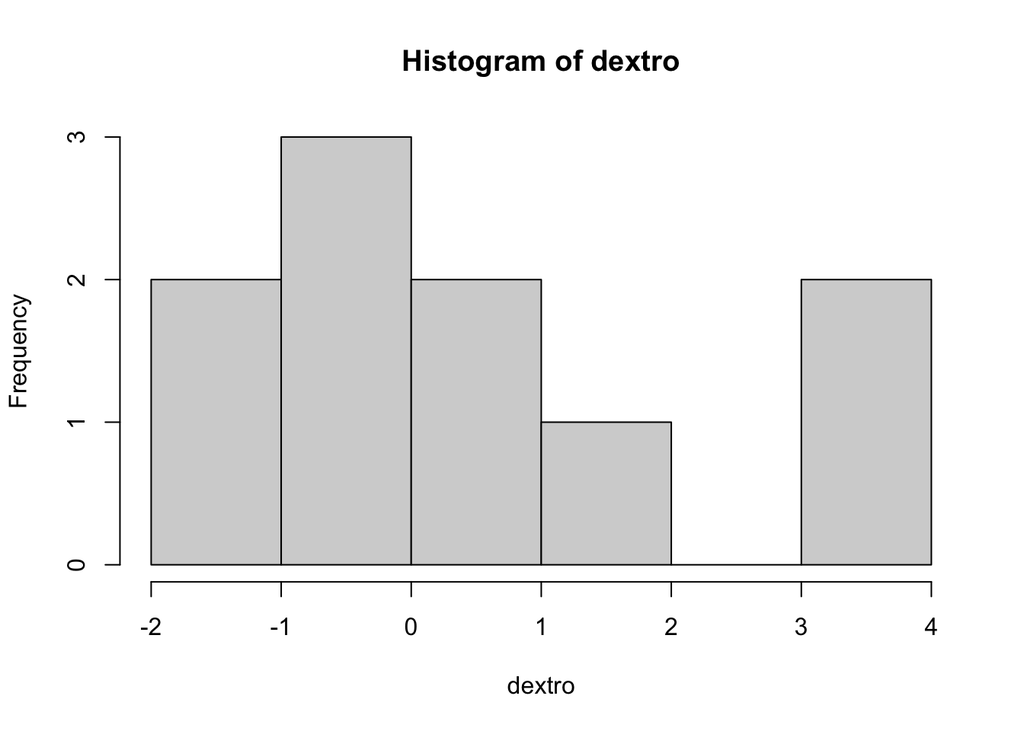

```r
hist(dextro)
```

skewed: depends on the length of tails

- Provide a 95% confidence interval for the average increase in hours’ sleep using Dextro-.

```r
# type your code here
n = 10
q = qt(0.975, df = n-1)
q
```

```
## [1] 2.262157
```

```r
mean + c(-1,1)* q * sigma / sqrt(n)
```

```
## [1] -0.5297804  2.0297804
```

- Would we reject a two-sided test that Dextro makes no difference to the duration of sleep at the 5% level of significance? Explain.
2. Below is the data for “Laevo”. The data has been slightly altered, so its not the same as Student’s original paper. Repeat the above steps now using the “Laevo” data.

```r
laevo = c(1.9, 10, 1.1, .1, -.1, 4.4, 5.5, 1.6, 4.6, 3.4)
```

- Compute the sample mean and SD

```r
# type your code here
mu2 = mean(laevo)
sigma2 = sd(laevo)
mu2
```

```
## [1] 3.25
```

```r
sigma2
```

```
## [1] 3.056959
```

- Is it reasonable to assume that this is a sample from an “approximately normal box”? Use some plots to check this.

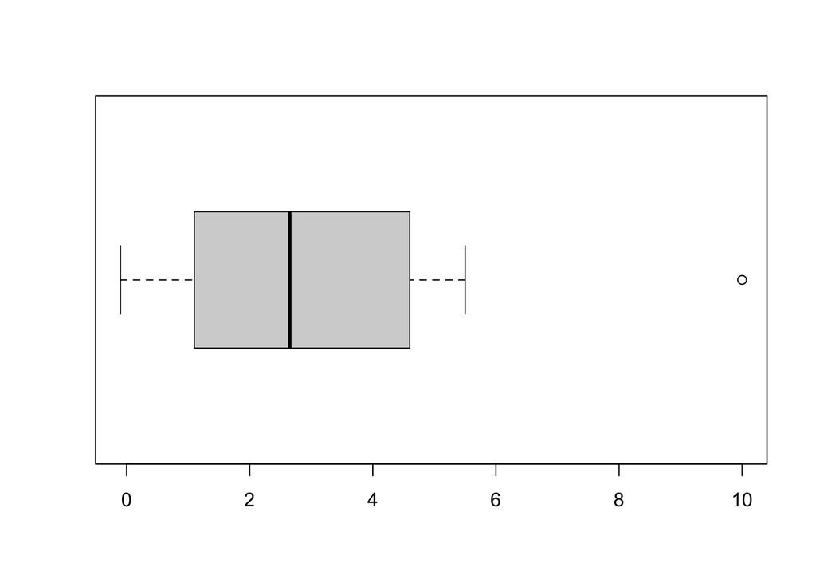

```r
# type your code here
boxplot(laevo,horizontal = TRUE)
```

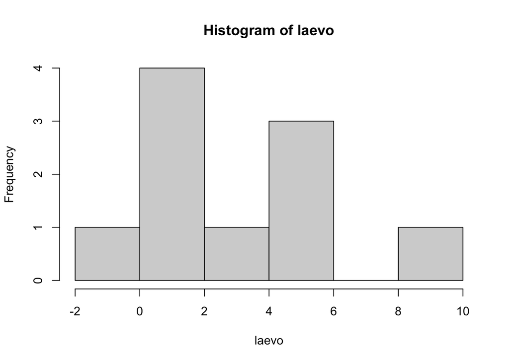

```r
hist(laevo)
```

- Provide a 95% confidence interval for the average increase in hours’ sleep using Laevo.

```r
# type your code here
qt(0.975,n-1)
```

```
## [1] 2.262157
```

```r
mu2 + c(-1,1) * sigma2/sqrt(n-1)
```

```
## [1] 2.231014 4.268986
```

- Would we reject a two-side test that Laevo makes no difference to the duration of sleep at the 5% level of significance? Explain.

3. Now use the bootstrap principle to construct a 95% confidence interval.
- Create 10K bootstrap t-statistics, using the sample as the original box.

```r
# write your code here
samp = sample(laevo, size = length(laevo),replace =TRUE)

(mean(samp) -mean(laevo))/(sd(samp)/sqrt(length(samp)))
```

```
## [1] -1.65225
```

- Plot a histogram of the bootstrap t-statistics and compare it to the appropriate t-distribution. Does the t-distribution provide a good approximation to the histogram?

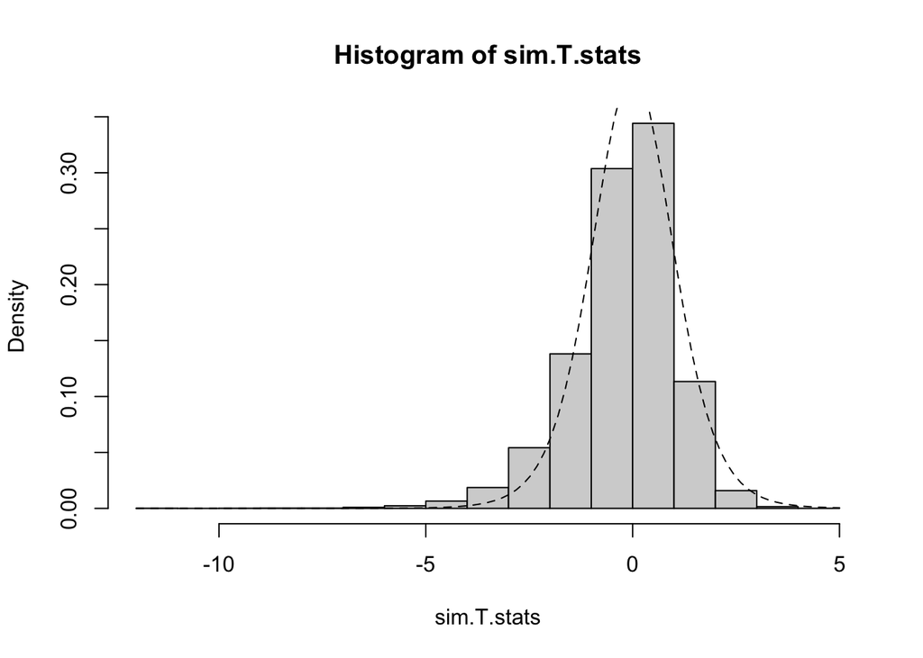

```r
#write your code here
sim.T.stats = 0
for(i in 1:10000){
  samp = sample(laevo, size = length(laevo),replace =TRUE)
  sim.T.stats[i] = (mean(samp) -mean(laevo))/(sd(samp)/sqrt(length(samp)))
}
hist(sim.T.stats,pr =T)
curve(dt(x,df = 9),add =T, lty = 2)
```

- Now construct the 95% confidence interval. Compare the confidence interval from the last question.

```r
#write your code here
quantile(sim.T.stats,points = c(0.25,0.975))
```

```
##           0%          25%          50%          75%         100%
## -11.28095255  -0.86423227  -0.06359333   0.59664436   4.61399619
```